# Cyclistic bike-share analysis case study

Fernanda Alfian

2022-03-10

## Scenario

You are a junior data analyst working in the marketing analyst team at Cyclistic, a bike-share company in Chicago. The directorof marketing believes the company’s future success depends on maximizing the number of annual memberships. Therefore, your team wants to understand how casual riders and annual members use Cyclistic bikes diﬀerently. From these insights, your team will design a new marketing strategy to convert casual riders into annual members. But ﬁrst, Cyclistic executives must approve your recommendations, so they must be backed up with compelling data insights and professional data visualizations.

## Setting up my packages

We need to set the dictionary to helps us to input, process, and visualize data. We need to install some packages like tidyverse, ggplot2, dplyr, readr.

This package will help to wragle the data

This package will help to visualize the data

This package will help to wragle the data

This package will help to read the .csv files data

```r
library("lubridate")
```

## Collect the data

#### Import the .csv files data

We import 13 .csv files data, from January 2021 until Januari 2022 from local computer. Rename for each data into format : Month_Year

The data are downloaded from [this link](https://divvy-tripdata.s3.amazonaws.com/index.html)

```r
Jan_2021 <- read.csv("C:\\Users\\ferna\\OneDrive\\Documents\\Case Study Coursera\\divvy-tripdata\\202101-divvy-tripdata.csv")
Feb_2021 <- read.csv("C:\\Users\\ferna\\OneDrive\\Documents\\Case Study Coursera\\divvy-tripdata\\202102-divvy-tripdata.csv")
Mar_2021 <- read.csv("C:\\Users\\ferna\\OneDrive\\Documents\\Case Study Coursera\\divvy-tripdata\\202103-divvy-tripdata.csv")
Apr_2021 <- read.csv("C:\\Users\\ferna\\OneDrive\\Documents\\Case Study Coursera\\divvy-tripdata\\202104-divvy-tripdata.csv")
May_2021 <- read.csv("C:\\Users\\ferna\\OneDrive\\Documents\\Case Study Coursera\\divvy-tripdata\\202105-divvy-tripdata.csv")
Jun_2021 <- read.csv("C:\\Users\\ferna\\OneDrive\\Documents\\Case Study Coursera\\divvy-tripdata\\202106-divvy-tripdata.csv")
Jul_2021 <- read.csv("C:\\Users\\ferna\\OneDrive\\Documents\\Case Study Coursera\\divvy-tripdata\\202107-divvy-tripdata.csv")
Aug_2021 <- read.csv("C:\\Users\\ferna\\OneDrive\\Documents\\Case Study Coursera\\divvy-tripdata\\202108-divvy-tripdata.csv")
Sep_2021 <- read.csv("C:\\Users\\ferna\\OneDrive\\Documents\\Case Study Coursera\\divvy-tripdata\\202109-divvy-tripdata.csv")
Oct_2021 <- read.csv("C:\\Users\\ferna\\OneDrive\\Documents\\Case Study Coursera\\divvy-tripdata\\202110-divvy-tripdata.csv")
Nov_2021 <- read.csv("C:\\Users\\ferna\\OneDrive\\Documents\\Case Study Coursera\\divvy-tripdata\\202111-divvy-tripdata.csv")
Dec_2021 <- read.csv("C:\\Users\\ferna\\OneDrive\\Documents\\Case Study Coursera\\divvy-tripdata\\202112-divvy-tripdata.csv")
Jan_2022 <- read.csv("C:\\Users\\ferna\\OneDrive\\Documents\\Case Study Coursera\\divvy-tripdata\\202201-divvy-tripdata.csv")
```

## Data wrangling and combining into single file

We need to look that all files has the same column for each file. If there are some files has different column, we need to make the column name has same standard like other data.

```r
colnames(Jan_2021)
```

```
##  [1] "ride_id"            "rideable_type"      "started_at"
##  [4] "ended_at"           "start_station_name" "start_station_id"
##  [7] "end_station_name"   "end_station_id"     "start_lat"
## [10] "start_lng"          "end_lat"            "end_lng"
## [13] "member_casual"
```

```r
colnames(Feb_2021)
```

```
##  [1] "ride_id"            "rideable_type"      "started_at"
##  [4] "ended_at"           "start_station_name" "start_station_id"
##  [7] "end_station_name"   "end_station_id"     "start_lat"
## [10] "start_lng"          "end_lat"            "end_lng"
## [13] "member_casual"
```

```r
colnames(Mar_2021)
```

```
##  [1] "ride_id"            "rideable_type"      "started_at"
##  [4] "ended_at"           "start_station_name" "start_station_id"
##  [7] "end_station_name"   "end_station_id"     "start_lat"
## [10] "start_lng"          "end_lat"            "end_lng"
## [13] "member_casual"
```

```r
colnames(Apr_2021)
```

```
##  [1] "ride_id"            "rideable_type"      "started_at"
##  [4] "ended_at"           "start_station_name" "start_station_id"
##  [7] "end_station_name"   "end_station_id"     "start_lat"
## [10] "start_lng"          "end_lat"            "end_lng"
## [13] "member_casual"
```

```r
colnames(May_2021)
```

```
##  [1] "ride_id"            "rideable_type"      "started_at"
##  [4] "ended_at"           "start_station_name" "start_station_id"
##  [7] "end_station_name"   "end_station_id"     "start_lat"
## [10] "start_lng"          "end_lat"            "end_lng"
## [13] "member_casual"
```

```r
colnames(Jun_2021)
```

```
##  [1] "ride_id"            "rideable_type"      "started_at"
##  [4] "ended_at"           "start_station_name" "start_station_id"
##  [7] "end_station_name"   "end_station_id"     "start_lat"
## [10] "start_lng"          "end_lat"            "end_lng"
## [13] "member_casual"
```

```r
colnames(Jul_2021)
```

```
##  [1] "ride_id"            "rideable_type"      "started_at"
##  [4] "ended_at"           "start_station_name" "start_station_id"
##  [7] "end_station_name"   "end_station_id"     "start_lat"
## [10] "start_lng"          "end_lat"            "end_lng"
## [13] "member_casual"
```

```r
colnames(Aug_2021)
```

```
##  [1] "ride_id"            "rideable_type"      "started_at"
##  [4] "ended_at"           "start_station_name" "start_station_id"
##  [7] "end_station_name"   "end_station_id"     "start_lat"
## [10] "start_lng"          "end_lat"            "end_lng"
## [13] "member_casual"
```

```r
colnames(Sep_2021)
```

```
##  [1] "ride_id"            "rideable_type"      "started_at"
##  [4] "ended_at"           "start_station_name" "start_station_id"
##  [7] "end_station_name"   "end_station_id"     "start_lat"
## [10] "start_lng"          "end_lat"            "end_lng"
## [13] "member_casual"
```

```r
colnames(Oct_2021)
```

```
##  [1] "ride_id"            "rideable_type"      "started_at"
##  [4] "ended_at"           "start_station_name" "start_station_id"
##  [7] "end_station_name"   "end_station_id"     "start_lat"
## [10] "start_lng"          "end_lat"            "end_lng"
## [13] "member_casual"
```

```r
colnames(Nov_2021)
```

```
##  [1] "ride_id"            "rideable_type"      "started_at"
##  [4] "ended_at"           "start_station_name" "start_station_id"
##  [7] "end_station_name"   "end_station_id"     "start_lat"
## [10] "start_lng"          "end_lat"            "end_lng"
## [13] "member_casual"
```

```r
colnames(Dec_2021)
```

```
##  [1] "ride_id"            "rideable_type"      "started_at"
##  [4] "ended_at"           "start_station_name" "start_station_id"
##  [7] "end_station_name"   "end_station_id"     "start_lat"
## [10] "start_lng"          "end_lat"            "end_lng"
## [13] "member_casual"
```

```r
colnames(Jan_2022)
```

```
##  [1] "ride_id"            "rideable_type"      "started_at"
##  [4] "ended_at"           "start_station_name" "start_station_id"
##  [7] "end_station_name"   "end_station_id"     "start_lat"
## [10] "start_lng"          "end_lat"            "end_lng"
## [13] "member_casual"
```

Note: All of files has same column. Now, we can move to next step.

We want to looking for the data type for each files. We need to make sure that for each files has same data type. That helps us to change the data type together if it needed

```r
str(Jan_2021)
```

```
## 'data.frame':    96834 obs. of  13 variables:
##  $ ride_id           : chr  "E19E6F1B8D4C42ED" "DC88F20C2C55F27F" "EC45C94683FE3F27" "4FA453A75AE377DB" ...
##  $ rideable_type     : chr  "electric_bike" "electric_bike" "electric_bike" "electric_bike" ...
##  $ started_at        : chr  "2021-01-23 16:14:19" "2021-01-27 18:43:08" "2021-01-21 22:35:54" "2021-01-07 13:31:13" ...
##  $ ended_at          : chr  "2021-01-23 16:24:44" "2021-01-27 18:47:12" "2021-01-21 22:37:14" "2021-01-07 13:42:55" ...
##  $ start_station_name: chr  "California Ave & Cortez St" "California Ave & Cortez St" "California Ave & Cortez St" "California Ave & Cortez St" ...
##  $ start_station_id  : chr  "17660" "17660" "17660" "17660" ...
##  $ end_station_name  : chr  "" "" "" "" ...
##  $ end_station_id    : chr  "" "" "" "" ...
##  $ start_lat         : num  41.9 41.9 41.9 41.9 41.9 ...
##  $ start_lng         : num  -87.7 -87.7 -87.7 -87.7 -87.7 ...
##  $ end_lat           : num  41.9 41.9 41.9 41.9 41.9 ...
##  $ end_lng           : num  -87.7 -87.7 -87.7 -87.7 -87.7 ...
##  $ member_casual     : chr  "member" "member" "member" "member" ...
```

```r
str(Feb_2021)
```

```
## 'data.frame':    49622 obs. of  13 variables:
##  $ ride_id           : chr  "89E7AA6C29227EFF" "0FEFDE2603568365" "E6159D746B2DBB91" "B32D3199F1C2E75B" ...
##  $ rideable_type     : chr  "classic_bike" "classic_bike" "electric_bike" "classic_bike" ...
##  $ started_at        : chr  "2021-02-12 16:14:56" "2021-02-14 17:52:38" "2021-02-09 19:10:18" "2021-02-02 17:49:41" ...
##  $ ended_at          : chr  "2021-02-12 16:21:43" "2021-02-14 18:12:09" "2021-02-09 19:19:10" "2021-02-02 17:54:06" ...
##  $ start_station_name: chr  "Glenwood Ave & Touhy Ave" "Glenwood Ave & Touhy Ave" "Clark St & Lake St" "Wood St & Chicago Ave" ...
##  $ start_station_id  : chr  "525" "525" "KA1503000012" "637" ...
##  $ end_station_name  : chr  "Sheridan Rd & Columbia Ave" "Bosworth Ave & Howard St" "State St & Randolph St" "Honore St & Division St" ...
##  $ end_station_id    : chr  "660" "16806" "TA1305000029" "TA1305000034" ...
##  $ start_lat         : num  42 42 41.9 41.9 41.8 ...
##  $ start_lng         : num  -87.7 -87.7 -87.6 -87.7 -87.6 ...
##  $ end_lat           : num  42 42 41.9 41.9 41.8 ...
##  $ end_lng           : num  -87.7 -87.7 -87.6 -87.7 -87.6 ...
##  $ member_casual     : chr  "member" "casual" "member" "member" ...
```

```r
str(Mar_2021)
```

```
## 'data.frame':    228496 obs. of  13 variables:
##  $ ride_id           : chr  "CFA86D4455AA1030" "30D9DC61227D1AF3" "846D87A15682A284" "994D05AA75A168F2" ...
##  $ rideable_type     : chr  "classic_bike" "classic_bike" "classic_bike" "classic_bike" ...
##  $ started_at        : chr  "2021-03-16 08:32:30" "2021-03-28 01:26:28" "2021-03-11 21:17:29" "2021-03-11 13:26:42" ...
##  $ ended_at          : chr  "2021-03-16 08:36:34" "2021-03-28 01:36:55" "2021-03-11 21:33:53" "2021-03-11 13:55:41" ...
##  $ start_station_name: chr  "Humboldt Blvd & Armitage Ave" "Humboldt Blvd & Armitage Ave" "Shields Ave & 28th Pl" "Winthrop Ave & Lawrence Ave" ...
##  $ start_station_id  : chr  "15651" "15651" "15443" "TA1308000021" ...
##  $ end_station_name  : chr  "Stave St & Armitage Ave" "Central Park Ave & Bloomingdale Ave" "Halsted St & 35th St" "Broadway & Sheridan Rd" ...
##  $ end_station_id    : chr  "13266" "18017" "TA1308000043" "13323" ...
##  $ start_lat         : num  41.9 41.9 41.8 42 42 ...
##  $ start_lng         : num  -87.7 -87.7 -87.6 -87.7 -87.7 ...
##  $ end_lat           : num  41.9 41.9 41.8 42 42.1 ...
##  $ end_lng           : num  -87.7 -87.7 -87.6 -87.6 -87.7 ...
##  $ member_casual     : chr  "casual" "casual" "casual" "casual" ...
```

```r
str(Apr_2021)
```

```
## 'data.frame':    337230 obs. of  13 variables:
##  $ ride_id           : chr  "6C992BD37A98A63F" "1E0145613A209000" "E498E15508A80BAD" "1887262AD101C604" ...
##  $ rideable_type     : chr  "classic_bike" "docked_bike" "docked_bike" "classic_bike" ...
##  $ started_at        : chr  "2021-04-12 18:25:36" "2021-04-27 17:27:11" "2021-04-03 12:42:45" "2021-04-17 09:17:42" ...
##  $ ended_at          : chr  "2021-04-12 18:56:55" "2021-04-27 18:31:29" "2021-04-07 11:40:24" "2021-04-17 09:42:48" ...
##  $ start_station_name: chr  "State St & Pearson St" "Dorchester Ave & 49th St" "Loomis Blvd & 84th St" "Honore St & Division St" ...
##  $ start_station_id  : chr  "TA1307000061" "KA1503000069" "20121" "TA1305000034" ...
##  $ end_station_name  : chr  "Southport Ave & Waveland Ave" "Dorchester Ave & 49th St" "Loomis Blvd & 84th St" "Southport Ave & Waveland Ave" ...
##  $ end_station_id    : chr  "13235" "KA1503000069" "20121" "13235" ...
##  $ start_lat         : num  41.9 41.8 41.7 41.9 41.7 ...
##  $ start_lng         : num  -87.6 -87.6 -87.7 -87.7 -87.7 ...
##  $ end_lat           : num  41.9 41.8 41.7 41.9 41.7 ...
##  $ end_lng           : num  -87.7 -87.6 -87.7 -87.7 -87.7 ...
##  $ member_casual     : chr  "member" "casual" "casual" "member" ...
```

```r
str(May_2021)
```

```
## 'data.frame':    531633 obs. of  13 variables:
##  $ ride_id           : chr  "C809ED75D6160B2A" "DD59FDCE0ACACAF3" "0AB83CB88C43EFC2" "7881AC6D39110C60" ...
##  $ rideable_type     : chr  "electric_bike" "electric_bike" "electric_bike" "electric_bike" ...
##  $ started_at        : chr  "2021-05-30 11:58:15" "2021-05-30 11:29:14" "2021-05-30 14:24:01" "2021-05-30 14:25:51" ...
##  $ ended_at          : chr  "2021-05-30 12:10:39" "2021-05-30 12:14:09" "2021-05-30 14:25:13" "2021-05-30 14:41:04" ...
##  $ start_station_name: chr  "" "" "" "" ...
##  $ start_station_id  : chr  "" "" "" "" ...
##  $ end_station_name  : chr  "" "" "" "" ...
##  $ end_station_id    : chr  "" "" "" "" ...
##  $ start_lat         : num  41.9 41.9 41.9 41.9 41.9 ...
##  $ start_lng         : num  -87.6 -87.6 -87.7 -87.7 -87.7 ...
##  $ end_lat           : num  41.9 41.8 41.9 41.9 41.9 ...
##  $ end_lng           : num  -87.6 -87.6 -87.7 -87.7 -87.7 ...
##  $ member_casual     : chr  "casual" "casual" "casual" "casual" ...
```

```r
str(Jun_2021)
```

```
## 'data.frame':    729595 obs. of  13 variables:
##  $ ride_id           : chr  "99FEC93BA843FB20" "06048DCFC8520CAF" "9598066F68045DF2" "B03C0FE48C412214" ...
##  $ rideable_type     : chr  "electric_bike" "electric_bike" "electric_bike" "electric_bike" ...
##  $ started_at        : chr  "2021-06-13 14:31:28" "2021-06-04 11:18:02" "2021-06-04 09:49:35" "2021-06-03 19:56:05" ...
##  $ ended_at          : chr  "2021-06-13 14:34:11" "2021-06-04 11:24:19" "2021-06-04 09:55:34" "2021-06-03 20:21:55" ...
##  $ start_station_name: chr  "" "" "" "" ...
##  $ start_station_id  : chr  "" "" "" "" ...
##  $ end_station_name  : chr  "" "" "" "" ...
##  $ end_station_id    : chr  "" "" "" "" ...
##  $ start_lat         : num  41.8 41.8 41.8 41.8 41.8 ...
##  $ start_lng         : num  -87.6 -87.6 -87.6 -87.6 -87.6 ...
##  $ end_lat           : num  41.8 41.8 41.8 41.8 41.8 ...
##  $ end_lng           : num  -87.6 -87.6 -87.6 -87.6 -87.6 ...
##  $ member_casual     : chr  "member" "member" "member" "member" ...
```

```r
str(Jul_2021)
```

```
## 'data.frame':    822410 obs. of  13 variables:
##  $ ride_id           : chr  "0A1B623926EF4E16" "B2D5583A5A5E76EE" "6F264597DDBF427A" "379B58EAB20E8AA5" ...
##  $ rideable_type     : chr  "docked_bike" "classic_bike" "classic_bike" "classic_bike" ...
##  $ started_at        : chr  "2021-07-02 14:44:36" "2021-07-07 16:57:42" "2021-07-25 11:30:55" "2021-07-08 22:08:30" ...
##  $ ended_at          : chr  "2021-07-02 15:19:58" "2021-07-07 17:16:09" "2021-07-25 11:48:45" "2021-07-08 22:23:32" ...
##  $ start_station_name: chr  "Michigan Ave & Washington St" "California Ave & Cortez St" "Wabash Ave & 16th St" "California Ave & Cortez St" ...
##  $ start_station_id  : chr  "13001" "17660" "SL-012" "17660" ...
##  $ end_station_name  : chr  "Halsted St & North Branch St" "Wood St & Hubbard St" "Rush St & Hubbard St" "Carpenter St & Huron St" ...
##  $ end_station_id    : chr  "KA1504000117" "13432" "KA1503000044" "13196" ...
##  $ start_lat         : num  41.9 41.9 41.9 41.9 41.9 ...
##  $ start_lng         : num  -87.6 -87.7 -87.6 -87.7 -87.7 ...
##  $ end_lat           : num  41.9 41.9 41.9 41.9 41.9 ...
##  $ end_lng           : num  -87.6 -87.7 -87.6 -87.7 -87.7 ...
##  $ member_casual     : chr  "casual" "casual" "member" "member" ...
```

```r
str(Aug_2021)
```

```
## 'data.frame':    804352 obs. of  13 variables:
##  $ ride_id           : chr  "99103BB87CC6C1BB" "EAFCCCFB0A3FC5A1" "9EF4F46C57AD234D" "5834D3208BFAF1DA" ...
##  $ rideable_type     : chr  "electric_bike" "electric_bike" "electric_bike" "electric_bike" ...
##  $ started_at        : chr  "2021-08-10 17:15:49" "2021-08-10 17:23:14" "2021-08-21 02:34:23" "2021-08-21 06:52:55" ...
##  $ ended_at          : chr  "2021-08-10 17:22:44" "2021-08-10 17:39:24" "2021-08-21 02:50:36" "2021-08-21 07:08:13" ...
##  $ start_station_name: chr  "" "" "" "" ...
##  $ start_station_id  : chr  "" "" "" "" ...
##  $ end_station_name  : chr  "" "" "" "" ...
##  $ end_station_id    : chr  "" "" "" "" ...
##  $ start_lat         : num  41.8 41.8 42 42 41.8 ...
##  $ start_lng         : num  -87.7 -87.7 -87.7 -87.7 -87.6 ...
##  $ end_lat           : num  41.8 41.8 42 42 41.8 ...
##  $ end_lng           : num  -87.7 -87.6 -87.7 -87.7 -87.6 ...
##  $ member_casual     : chr  "member" "member" "member" "member" ...
```

```r
str(Sep_2021)
```

```
## 'data.frame':    756147 obs. of  13 variables:
##  $ ride_id           : chr  "9DC7B962304CBFD8" "F930E2C6872D6B32" "6EF72137900BB910" "78D1DE133B3DBF55" ...
##  $ rideable_type     : chr  "electric_bike" "electric_bike" "electric_bike" "electric_bike" ...
##  $ started_at        : chr  "2021-09-28 16:07:10" "2021-09-28 14:24:51" "2021-09-28 00:20:16" "2021-09-28 14:51:17" ...
##  $ ended_at          : chr  "2021-09-28 16:09:54" "2021-09-28 14:40:05" "2021-09-28 00:23:57" "2021-09-28 15:00:06" ...
##  $ start_station_name: chr  "" "" "" "" ...
##  $ start_station_id  : chr  "" "" "" "" ...
##  $ end_station_name  : chr  "" "" "" "" ...
##  $ end_station_id    : chr  "" "" "" "" ...
##  $ start_lat         : num  41.9 41.9 41.8 41.8 41.9 ...
##  $ start_lng         : num  -87.7 -87.6 -87.7 -87.7 -87.7 ...
##  $ end_lat           : num  41.9 42 41.8 41.8 41.9 ...
##  $ end_lng           : num  -87.7 -87.7 -87.7 -87.7 -87.7 ...
##  $ member_casual     : chr  "casual" "casual" "casual" "casual" ...
```

```r
str(Oct_2021)
```

```
## 'data.frame':    631226 obs. of  13 variables:
##  $ ride_id           : chr  "620BC6107255BF4C" "4471C70731AB2E45" "26CA69D43D15EE14" "362947F0437E1514" ...
##  $ rideable_type     : chr  "electric_bike" "electric_bike" "electric_bike" "electric_bike" ...
##  $ started_at        : chr  "2021-10-22 12:46:42" "2021-10-21 09:12:37" "2021-10-16 16:28:39" "2021-10-16 16:17:48" ...
##  $ ended_at          : chr  "2021-10-22 12:49:50" "2021-10-21 09:14:14" "2021-10-16 16:36:26" "2021-10-16 16:19:03" ...
##  $ start_station_name: chr  "Kingsbury St & Kinzie St" "" "" "" ...
##  $ start_station_id  : chr  "KA1503000043" "" "" "" ...
##  $ end_station_name  : chr  "" "" "" "" ...
##  $ end_station_id    : chr  "" "" "" "" ...
##  $ start_lat         : num  41.9 41.9 41.9 41.9 41.9 ...
##  $ start_lng         : num  -87.6 -87.7 -87.7 -87.7 -87.7 ...
##  $ end_lat           : num  41.9 41.9 41.9 41.9 41.9 ...
##  $ end_lng           : num  -87.6 -87.7 -87.7 -87.7 -87.7 ...
##  $ member_casual     : chr  "member" "member" "member" "member" ...
```

```r
str(Nov_2021)
```

```
## 'data.frame':    359978 obs. of  13 variables:
##  $ ride_id           : chr  "7C00A93E10556E47" "90854840DFD508BA" "0A7D10CDD144061C" "2F3BE33085BCFF02" ...
##  $ rideable_type     : chr  "electric_bike" "electric_bike" "electric_bike" "electric_bike" ...
##  $ started_at        : chr  "2021-11-27 13:27:38" "2021-11-27 13:38:25" "2021-11-26 22:03:34" "2021-11-27 09:56:49" ...
##  $ ended_at          : chr  "2021-11-27 13:46:38" "2021-11-27 13:56:10" "2021-11-26 22:05:56" "2021-11-27 10:01:50" ...
##  $ start_station_name: chr  "" "" "" "" ...
##  $ start_station_id  : chr  "" "" "" "" ...
##  $ end_station_name  : chr  "" "" "" "" ...
##  $ end_station_id    : chr  "" "" "" "" ...
##  $ start_lat         : num  41.9 42 42 41.9 41.9 ...
##  $ start_lng         : num  -87.7 -87.7 -87.7 -87.8 -87.6 ...
##  $ end_lat           : num  42 41.9 42 41.9 41.9 ...
##  $ end_lng           : num  -87.7 -87.7 -87.7 -87.8 -87.6 ...
##  $ member_casual     : chr  "casual" "casual" "casual" "casual" ...
```

```r
str(Dec_2021)
```

```
## 'data.frame':    247540 obs. of  13 variables:
##  $ ride_id           : chr  "46F8167220E4431F" "73A77762838B32FD" "4CF42452054F59C5" "3278BA87BF698339" ...
##  $ rideable_type     : chr  "electric_bike" "electric_bike" "electric_bike" "classic_bike" ...
##  $ started_at        : chr  "2021-12-07 15:06:07" "2021-12-11 03:43:29" "2021-12-15 23:10:28" "2021-12-26 16:16:10" ...
##  $ ended_at          : chr  "2021-12-07 15:13:42" "2021-12-11 04:10:23" "2021-12-15 23:23:14" "2021-12-26 16:30:53" ...
##  $ start_station_name: chr  "Laflin St & Cullerton St" "LaSalle Dr & Huron St" "Halsted St & North Branch St" "Halsted St & North Branch St" ...
##  $ start_station_id  : chr  "13307" "KP1705001026" "KA1504000117" "KA1504000117" ...
##  $ end_station_name  : chr  "Morgan St & Polk St" "Clarendon Ave & Leland Ave" "Broadway & Barry Ave" "LaSalle Dr & Huron St" ...
##  $ end_station_id    : chr  "TA1307000130" "TA1307000119" "13137" "KP1705001026" ...
##  $ start_lat         : num  41.9 41.9 41.9 41.9 41.9 ...
##  $ start_lng         : num  -87.7 -87.6 -87.6 -87.6 -87.7 ...
##  $ end_lat           : num  41.9 42 41.9 41.9 41.9 ...
##  $ end_lng           : num  -87.7 -87.7 -87.6 -87.6 -87.6 ...
##  $ member_casual     : chr  "member" "casual" "member" "member" ...
```

```r
str(Jan_2022)
```

```
## 'data.frame':    103770 obs. of  13 variables:
##  $ ride_id           : chr  "C2F7DD78E82EC875" "A6CF8980A652D272" "BD0F91DFF741C66D" "CBB80ED419105406" ...
##  $ rideable_type     : chr  "electric_bike" "electric_bike" "classic_bike" "classic_bike" ...
##  $ started_at        : chr  "2022-01-13 11:59:47" "2022-01-10 08:41:56" "2022-01-25 04:53:40" "2022-01-04 00:18:04" ...
##  $ ended_at          : chr  "2022-01-13 12:02:44" "2022-01-10 08:46:17" "2022-01-25 04:58:01" "2022-01-04 00:33:00" ...
##  $ start_station_name: chr  "Glenwood Ave & Touhy Ave" "Glenwood Ave & Touhy Ave" "Sheffield Ave & Fullerton Ave" "Clark St & Bryn Mawr Ave" ...
##  $ start_station_id  : chr  "525" "525" "TA1306000016" "KA1504000151" ...
##  $ end_station_name  : chr  "Clark St & Touhy Ave" "Clark St & Touhy Ave" "Greenview Ave & Fullerton Ave" "Paulina St & Montrose Ave" ...
##  $ end_station_id    : chr  "RP-007" "RP-007" "TA1307000001" "TA1309000021" ...
##  $ start_lat         : num  42 42 41.9 42 41.9 ...
##  $ start_lng         : num  -87.7 -87.7 -87.7 -87.7 -87.6 ...
##  $ end_lat           : num  42 42 41.9 42 41.9 ...
##  $ end_lng           : num  -87.7 -87.7 -87.7 -87.7 -87.6 ...
##  $ member_casual     : chr  "casual" "casual" "member" "casual" ...
```

From the results, we can see that started_at and ended_at column has char data type. We need to convert the data type char to date. Because all the columns name are on the same position, we can change the data type together in single file not individualy, after combining all of files into single file.

```r
all_trips_data <- rbind(Jan_2021, Feb_2021, Mar_2021, Apr_2021, May_2021, Jun_2021, Jul_2021, Aug_2021, Sep_2021, Oct_2021, Nov_2021, Dec_2021, Jan_2022)
```

look the column name

```r
head(all_trips_data)
```

```
##            ride_id rideable_type          started_at            ended_at
## 1 E19E6F1B8D4C42ED electric_bike 2021-01-23 16:14:19 2021-01-23 16:24:44
## 2 DC88F20C2C55F27F electric_bike 2021-01-27 18:43:08 2021-01-27 18:47:12
## 3 EC45C94683FE3F27 electric_bike 2021-01-21 22:35:54 2021-01-21 22:37:14
## 4 4FA453A75AE377DB electric_bike 2021-01-07 13:31:13 2021-01-07 13:42:55
## 5 BE5E8EB4E7263A0B electric_bike 2021-01-23 02:24:02 2021-01-23 02:24:45
## 6 5D8969F88C773979 electric_bike 2021-01-09 14:24:07 2021-01-09 15:17:54
##           start_station_name start_station_id end_station_name end_station_id
## 1 California Ave & Cortez St            17660
## 2 California Ave & Cortez St            17660
## 3 California Ave & Cortez St            17660
## 4 California Ave & Cortez St            17660
## 5 California Ave & Cortez St            17660
## 6 California Ave & Cortez St            17660
##   start_lat start_lng end_lat end_lng member_casual
## 1  41.90034 -87.69674   41.89  -87.72        member
## 2  41.90033 -87.69671   41.90  -87.69        member
## 3  41.90031 -87.69664   41.90  -87.70        member
## 4  41.90040 -87.69666   41.92  -87.69        member
## 5  41.90033 -87.69670   41.90  -87.70        casual
## 6  41.90041 -87.69676   41.94  -87.71        casual
```

look for the data type

```r
str(all_trips_data)
```

```
## 'data.frame':    5698833 obs. of  13 variables:
##  $ ride_id           : chr  "E19E6F1B8D4C42ED" "DC88F20C2C55F27F" "EC45C94683FE3F27" "4FA453A75AE377DB" ...
##  $ rideable_type     : chr  "electric_bike" "electric_bike" "electric_bike" "electric_bike" ...
##  $ started_at        : chr  "2021-01-23 16:14:19" "2021-01-27 18:43:08" "2021-01-21 22:35:54" "2021-01-07 13:31:13" ...
##  $ ended_at          : chr  "2021-01-23 16:24:44" "2021-01-27 18:47:12" "2021-01-21 22:37:14" "2021-01-07 13:42:55" ...
##  $ start_station_name: chr  "California Ave & Cortez St" "California Ave & Cortez St" "California Ave & Cortez St" "California Ave & Cortez St" ...
##  $ start_station_id  : chr  "17660" "17660" "17660" "17660" ...
##  $ end_station_name  : chr  "" "" "" "" ...
##  $ end_station_id    : chr  "" "" "" "" ...
##  $ start_lat         : num  41.9 41.9 41.9 41.9 41.9 ...
##  $ start_lng         : num  -87.7 -87.7 -87.7 -87.7 -87.7 ...
##  $ end_lat           : num  41.9 41.9 41.9 41.9 41.9 ...
##  $ end_lng           : num  -87.7 -87.7 -87.7 -87.7 -87.7 ...
##  $ member_casual     : chr  "member" "member" "member" "member" ...
```

Change the data type char to date on started_at and ended_at column

```r
all_trips_data <- mutate(all_trips_data,
                         started_at = as.POSIXct(started_at),
                         ended_at = as.POSIXct(ended_at)
                         )
```

Look if the data type has change

```r
str(all_trips_data)
```

```
## 'data.frame':    5698833 obs. of  13 variables:
##  $ ride_id           : chr  "E19E6F1B8D4C42ED" "DC88F20C2C55F27F" "EC45C94683FE3F27" "4FA453A75AE377DB" ...
##  $ rideable_type     : chr  "electric_bike" "electric_bike" "electric_bike" "electric_bike" ...
##  $ started_at        : POSIXct, format: "2021-01-23 16:14:19" "2021-01-27 18:43:08" ...
##  $ ended_at          : POSIXct, format: "2021-01-23 16:24:44" "2021-01-27 18:47:12" ...
##  $ start_station_name: chr  "California Ave & Cortez St" "California Ave & Cortez St" "California Ave & Cortez St" "California Ave & Cortez St" ...
##  $ start_station_id  : chr  "17660" "17660" "17660" "17660" ...
##  $ end_station_name  : chr  "" "" "" "" ...
##  $ end_station_id    : chr  "" "" "" "" ...
##  $ start_lat         : num  41.9 41.9 41.9 41.9 41.9 ...
##  $ start_lng         : num  -87.7 -87.7 -87.7 -87.7 -87.7 ...
##  $ end_lat           : num  41.9 41.9 41.9 41.9 41.9 ...
##  $ end_lng           : num  -87.7 -87.7 -87.7 -87.7 -87.7 ...
##  $ member_casual     : chr  "member" "member" "member" "member" ...
```

Looking for summary of all_trips_data

```r
summary(all_trips_data)
```

```
##    ride_id          rideable_type        started_at
##  Length:5698833     Length:5698833     Min.   :2021-01-01 00:02:05
##  Class :character   Class :character   1st Qu.:2021-06-08 14:51:48
##  Mode  :character   Mode  :character   Median :2021-08-03 01:18:38
##                                        Mean   :2021-08-01 10:30:05
##                                        3rd Qu.:2021-09-27 15:07:19
##                                        Max.   :2022-01-31 23:58:37
##
##     ended_at                   start_station_name start_station_id
##  Min.   :2021-01-01 00:08:39   Length:5698833     Length:5698833
##  1st Qu.:2021-06-08 15:16:41   Class :character   Class :character
##  Median :2021-08-03 02:12:44   Mode  :character   Mode  :character
##  Mean   :2021-08-01 10:51:53
##  3rd Qu.:2021-09-27 15:27:45
##  Max.   :2022-02-01 01:46:16
##
##  end_station_name   end_station_id       start_lat       start_lng
##  Length:5698833     Length:5698833     Min.   :41.64   Min.   :-87.84
##  Class :character   Class :character   1st Qu.:41.88   1st Qu.:-87.66
##  Mode  :character   Mode  :character   Median :41.90   Median :-87.64
##                                        Mean   :41.90   Mean   :-87.65
##                                        3rd Qu.:41.93   3rd Qu.:-87.63
##                                        Max.   :45.64   Max.   :-73.80
##
##     end_lat         end_lng       member_casual
##  Min.   :41.39   Min.   :-88.97   Length:5698833
##  1st Qu.:41.88   1st Qu.:-87.66   Class :character
##  Median :41.90   Median :-87.64   Mode  :character
##  Mean   :41.90   Mean   :-87.65
##  3rd Qu.:41.93   3rd Qu.:-87.63
##  Max.   :42.17   Max.   :-87.49
##  NA's   :4857    NA's   :4857
```

We can see the summary of the all_trips_data. But these are not that we’re looking for.

There are several problems for this data. (1) We want to see the date, month, hour of trip, day, day of week. We create several columns. (2) We want to see the trip length of each trip. We create a new column to calculate the different between ended_et and started_at. (3) We want to remove some data that shows negative value of trip length. (4) Some of stations are warehouse and testing of divvy bikes and we need to clean it up from the data. (5) We want to see if the rides return the shared bike on the same station as the started station We create a column to see it.

All of these problems, we can see the solutions from next section.

## Data cleaning and data exploration

1. We want to see the date, month, hour of trip, day, day of week. We create several columns.

```r
all_trips_data$date <- as.Date(all_trips_data$started_at)
all_trips_data$month <- format(as.Date(all_trips_data$started_at), "%m")
all_trips_data$trip_hour <- (format(all_trips_data$started_at, "%H"))
all_trips_data$day <- format(as.Date(all_trips_data$started_at), "%w")
all_trips_data$day_of_Week <- format(as.Date(all_trips_data$started_at), "%A")
all_trips_data$datetime <- (format(all_trips_data$started_at, "%H:%M:%S"))
```

2. We want to see the trip length of each trip. We create a new column to calculate the different between ended_et and started_at.

```r
all_trips_data$ride_length <- difftime(all_trips_data$ended_at, all_trips_data$started_at)
```

We checked the data column and data type is correct, and we can move to the next step.

```r
head(all_trips_data)
```

```
##            ride_id rideable_type          started_at            ended_at
## 1 E19E6F1B8D4C42ED electric_bike 2021-01-23 16:14:19 2021-01-23 16:24:44
## 2 DC88F20C2C55F27F electric_bike 2021-01-27 18:43:08 2021-01-27 18:47:12
## 3 EC45C94683FE3F27 electric_bike 2021-01-21 22:35:54 2021-01-21 22:37:14
## 4 4FA453A75AE377DB electric_bike 2021-01-07 13:31:13 2021-01-07 13:42:55
## 5 BE5E8EB4E7263A0B electric_bike 2021-01-23 02:24:02 2021-01-23 02:24:45
## 6 5D8969F88C773979 electric_bike 2021-01-09 14:24:07 2021-01-09 15:17:54
##           start_station_name start_station_id end_station_name end_station_id
## 1 California Ave & Cortez St            17660
## 2 California Ave & Cortez St            17660
## 3 California Ave & Cortez St            17660
## 4 California Ave & Cortez St            17660
## 5 California Ave & Cortez St            17660
## 6 California Ave & Cortez St            17660
##   start_lat start_lng end_lat end_lng member_casual       date month trip_hour
## 1  41.90034 -87.69674   41.89  -87.72        member 2021-01-23    01        16
## 2  41.90033 -87.69671   41.90  -87.69        member 2021-01-27    01        18
## 3  41.90031 -87.69664   41.90  -87.70        member 2021-01-21    01        22
## 4  41.90040 -87.69666   41.92  -87.69        member 2021-01-07    01        13
## 5  41.90033 -87.69670   41.90  -87.70        casual 2021-01-22    01        02
## 6  41.90041 -87.69676   41.94  -87.71        casual 2021-01-09    01        14
##   day day_of_Week datetime ride_length
## 1   6    Saturday 16:14:19    625 secs
## 2   3   Wednesday 18:43:08    244 secs
## 3   4    Thursday 22:35:54     80 secs
## 4   4    Thursday 13:31:13    702 secs
## 5   5      Friday 02:24:02     43 secs
## 6   6    Saturday 14:24:07   3227 secs
```

```r
str(all_trips_data)
```

```
## 'data.frame':    5698833 obs. of  20 variables:
##  $ ride_id           : chr  "E19E6F1B8D4C42ED" "DC88F20C2C55F27F" "EC45C94683FE3F27" "4FA453A75AE377DB" ...
##  $ rideable_type     : chr  "electric_bike" "electric_bike" "electric_bike" "electric_bike" ...
##  $ started_at        : POSIXct, format: "2021-01-23 16:14:19" "2021-01-27 18:43:08" ...
##  $ ended_at          : POSIXct, format: "2021-01-23 16:24:44" "2021-01-27 18:47:12" ...
##  $ start_station_name: chr  "California Ave & Cortez St" "California Ave & Cortez St" "California Ave & Cortez St" "California Ave & Cortez St" ...
##  $ start_station_id  : chr  "17660" "17660" "17660" "17660" ...
##  $ end_station_name  : chr  "" "" "" "" ...
##  $ end_station_id    : chr  "" "" "" "" ...
##  $ start_lat         : num  41.9 41.9 41.9 41.9 41.9 ...
##  $ start_lng         : num  -87.7 -87.7 -87.7 -87.7 -87.7 ...
##  $ end_lat           : num  41.9 41.9 41.9 41.9 41.9 ...
##  $ end_lng           : num  -87.7 -87.7 -87.7 -87.7 -87.7 ...
##  $ member_casual     : chr  "member" "member" "member" "member" ...
##  $ date              : Date, format: "2021-01-23" "2021-01-27" ...
##  $ month             : chr  "01" "01" "01" "01" ...
##  $ trip_hour         : chr  "16" "18" "22" "13" ...
##  $ day               : chr  "6" "3" "4" "4" ...
##  $ day_of_Week       : chr  "Saturday" "Wednesday" "Thursday" "Thursday" ...
##  $ datetime          : chr  "16:14:19" "18:43:08" "22:35:54" "13:31:13" ...
##  $ ride_length       : 'difftime' num  625 244 80 702 ...
##   ..- attr(*, "units")= chr "secs"
```

```r
is.numeric(all_trips_data$ride_length)
```

```
## [1] FALSE
```

```r
all_trips_data$ride_length <- as.numeric(as.character(all_trips_data$ride_length))
is.numeric(all_trips_data$ride_length)
```

```
## [1] TRUE
```

The data type is changed to numeric value

3. We want to remove some data that shows negative value of trip length.
4. Some of stations are warehouse and testing of divvy bikes and we need to clean it up from the data.

From this step, we create a new data frame, just want to see the number of observation. That can help us to see the percentage of number of observation will affect the main data frame if the number of obs in new data frame are deleted in main data frame.

```r
all_trips_data_ride_length_negative <- all_trips_data[(all_trips_data$ride_length<0),]
```

From this data frame, we can see total obs, and from this code it will be our reference for ride_length negative in main data_frame

```r
all_trips_na_lat_long <- all_trips_data[(all_trips_data$start_lat == "" | is.na(all_trips_data$start_lat) | all_trips_data$start_lng == "" | is.na(all_trips_data$start_lng) | all_trips_data$end_lat == "" | is.na(all_trips_data$end_lat) |  all_trips_data$end_lng == "" | is.na(all_trips_data$end_lng)),]
```

From this code / data frame, tell us about the latitude and longitute that has N/A values in data, and we can delete the data from main data frame.

```r
all_trips_na_stations <- all_trips_data [(all_trips_data$start_station_name == ""| is.na(all_trips_data$start_station_name) | all_trips_data$end_station_name == "" | is.na(all_trips_data$end_station_name)),]
```

There are a lot of data from N/A stations. From [divvy information website](https://divvybikes.com/pricing/day-pass), for day pass they have more flexibility to return the bike. We assume that they can just lock the bike in anywhere, not only on station.

From the data, there are some station that indicate the warehouse / testing bike of divvy station, and we delete it later.

We create a new data frame called all_trips_data_v2, to store our clean data.

```r
all_trips_data_v2 <- all_trips_data[!(all_trips_data$ride_length<0),]
```

```r
all_trips_data_v2 <- all_trips_data_v2[!(all_trips_data_v2$start_lat == "" | is.na(all_trips_data_v2$start_lat) | all_trips_data_v2$start_lng == "" | is.na(all_trips_data_v2$start_lng) | all_trips_data_v2$end_lat == "" | is.na(all_trips_data_v2$end_lat) |  all_trips_data_v2$end_lng == "" | is.na(all_trips_data_v2$end_lng)),]
```

```r
all_trips_data_v2 <- all_trips_data_v2 [!((all_trips_data_v2$start_station_name == "WATSON TESTING - DIVVY" & !is.na(all_trips_data_v2$start_station_name)) | (all_trips_data_v2$start_station_name == "HUBBARD BIKE-CHECKING (LBS-WH-TEST)" & !is.na(all_trips_data_v2$start_station_name)) | (all_trips_data_v2$start_station_name == "Base - 2132 W Hubbard Warehouse" & !is.na(all_trips_data_v2$start_station_name)) | (all_trips_data_v2$start_station_name == "Hubbard Bike-checking (LBS-WH-TEST)" & !is.na(all_trips_data_v2$start_station_name)) | (all_trips_data_v2$start_station_id == "Hubbard Bike-checking (LBS-WH-TEST)" & !is.na(all_trips_data_v2$start_station_id))),]
```

5. We want to see if the rides return the shared bike on the same station as the started station We create a column to see it.

```r
all_trips_data_v2 <- all_trips_data_v2 %>%
  mutate(start_end_same_station = case_when(
    all_trips_data_v2$start_station_name == all_trips_data_v2$end_station_name ~ "Yes",
    all_trips_data_v2$start_station_name != all_trips_data_v2$end_station_name ~ "No"))
```

We want to see the data type from new data frame

```r
str(all_trips_data_v2)
```

```
## 'data.frame':    5693504 obs. of  21 variables:
##  $ ride_id               : chr  "E19E6F1B8D4C42ED" "DC88F20C2C55F27F" "EC45C94683FE3F27" "4FA453A75AE377DB" ...
##  $ rideable_type         : chr  "electric_bike" "electric_bike" "electric_bike" "electric_bike" ...
##  $ started_at            : POSIXct, format: "2021-01-23 16:14:19" "2021-01-27 18:43:08" ...
##  $ ended_at              : POSIXct, format: "2021-01-23 16:24:44" "2021-01-27 18:47:12" ...
##  $ start_station_name    : chr  "California Ave & Cortez St" "California Ave & Cortez St" "California Ave & Cortez St" "California Ave & Cortez St" ...
##  $ start_station_id      : chr  "17660" "17660" "17660" "17660" ...
##  $ end_station_name      : chr  "" "" "" "" ...
##  $ end_station_id        : chr  "" "" "" "" ...
##  $ start_lat             : num  41.9 41.9 41.9 41.9 41.9 ...
##  $ start_lng             : num  -87.7 -87.7 -87.7 -87.7 -87.7 ...
##  $ end_lat               : num  41.9 41.9 41.9 41.9 41.9 ...
##  $ end_lng               : num  -87.7 -87.7 -87.7 -87.7 -87.7 ...
##  $ member_casual         : chr  "member" "member" "member" "member" ...
##  $ date                  : Date, format: "2021-01-23" "2021-01-27" ...
##  $ month                 : chr  "01" "01" "01" "01" ...
##  $ trip_hour             : chr  "16" "18" "22" "13" ...
##  $ day                   : chr  "6" "3" "4" "4" ...
##  $ day_of_Week           : chr  "Saturday" "Wednesday" "Thursday" "Thursday" ...
##  $ datetime              : chr  "16:14:19" "18:43:08" "22:35:54" "13:31:13" ...
##  $ ride_length           : num  625 244 80 702 43 ...
##  $ start_end_same_station: chr  "No" "No" "No" "No" ...
```

We want to change the trip_length from second format to minute rounded

```r
all_trips_data_v2$ride_length_min <- all_trips_data_v2$ride_length/60
all_trips_data_v2$ride_length_min <- round(all_trips_data_v2$ride_length_min, digits=0)
```

## Desctiptive Analysis

We want to see the number of rides for member and casual

```
## # A tibble: 2 x 2
##   member_casual   count
##   <chr>           <int>
## 1 casual        2543902
## 2 member        3149602
```

We want to see the mean, meadian, max of ride_length

```
##     Min.  1st Qu.   Median     Mean  3rd Qu.     Max.
##     0.00     7.00    12.00    20.85    22.00 55944.00
```

Compare ride_length for member and casual

```
##   all_trips_data_v2$member_casual all_trips_data_v2$ride_length_min
## 1                          casual                          30.18964
## 2                          member                          13.30576
```

```
##   all_trips_data_v2$member_casual all_trips_data_v2$ride_length_min
## 1                          casual                                16
## 2                          member                                10
```

```
##   all_trips_data_v2$member_casual all_trips_data_v2$ride_length_min
## 1                          casual                             55944
## 2                          member                              1500
```

```
##   all_trips_data_v2$member_casual all_trips_data_v2$ride_length_min
## 1                          casual                                 0
## 2                          member                                 0
```

We want to see the ride_length per day and for member and casual

```
##    all_trips_data_v2$member_casual all_trips_data_v2$day_of_Week
## 1                           casual                        Friday
## 2                           member                        Friday
## 3                           casual                        Monday
## 4                           member                        Monday
## 5                           casual                      Saturday
## 6                           member                      Saturday
## 7                           casual                        Sunday
## 8                           member                        Sunday
## 9                           casual                      Thursday
## 10                          member                      Thursday
## 11                          casual                       Tuesday
## 12                          member                       Tuesday
## 13                          casual                     Wednesday
## 14                          member                     Wednesday
##    all_trips_data_v2$ride_length_min
## 1                           28.96491
## 2                           13.13982
## 3                           29.80223
## 4                           12.85550
## 5                           32.90460
## 6                           14.89072
## 7                           35.33509
## 8                           15.01276
## 9                           26.43694
## 10                          12.49668
## 11                          26.61974
## 12                          12.56404
## 13                          26.06341
## 14                          12.59196
```

Because the day_of_week not shorted acending. We need to short the day_of_week acending order using levels

We can see the day_of_week is shorted acending

```
##    all_trips_data_v2$member_casual all_trips_data_v2$day_of_Week
## 1                           casual                        Monday
## 2                           member                        Monday
## 3                           casual                       Tuesday
## 4                           member                       Tuesday
## 5                           casual                     Wednesday
## 6                           member                     Wednesday
## 7                           casual                      Thursday
## 8                           member                      Thursday
## 9                           casual                        Friday
## 10                          member                        Friday
## 11                          casual                      Saturday
## 12                          member                      Saturday
## 13                          casual                        Sunday
## 14                          member                        Sunday
##    all_trips_data_v2$ride_length_min
## 1                           29.80223
## 2                           12.85550
## 3                           26.61974
## 4                           12.56404
## 5                           26.06341
## 6                           12.59196
## 7                           26.43694
## 8                           12.49668
## 9                           28.96491
## 10                          13.13982
## 11                          32.90460
## 12                          14.89072
## 13                          35.33509
## 14                          15.01276
```

```
##   all_trips_data_v2$member_casual all_trips_data_v2$ride_length_min
## 1                          casual                           2543902
## 2                          member                           3149602
```

We want to see the ride length for ridable type for member and casual

```
##   all_trips_data_v2$rideable_type all_trips_data_v2$member_casual
## 1                    classic_bike                          casual
## 2                     docked_bike                          casual
## 3                   electric_bike                          casual
## 4                    classic_bike                          member
## 5                     docked_bike                          member
## 6                   electric_bike                          member
##   all_trips_data_v2$ride_length_min
## 1                           1270360
## 2                            312986
## 3                            960556
## 4                           2031040
## 5                                 1
## 6                           1118561
```

We want to see the ride length for each days and member and casual

```
##    all_trips_data_v2$member_casual all_trips_data_v2$day_of_Week
## 1                           casual                        Monday
## 2                           member                        Monday
## 3                           casual                       Tuesday
## 4                           member                       Tuesday
## 5                           casual                     Wednesday
## 6                           member                     Wednesday
## 7                           casual                      Thursday
## 8                           member                      Thursday
## 9                           casual                        Friday
## 10                          member                        Friday
## 11                          casual                      Saturday
## 12                          member                      Saturday
## 13                          casual                        Sunday
## 14                          member                        Sunday
##    all_trips_data_v2$ride_length_min
## 1                             283436
## 2                             431891
## 3                             276579
## 4                             479502
## 5                             282408
## 6                             488375
## 7                             293808
## 8                             466043
## 9                             391061
## 10                            459913
## 11                            570646
## 12                            444453
## 13                            445964
## 14                            379425
```

We want to see the rides who start and ended the rides in same or other station

```
##   all_trips_data_v2$member_casual all_trips_data_v2$start_end_same_station
## 1                          casual                                       No
## 2                          member                                       No
## 3                          casual                                      Yes
## 4                          member                                      Yes
##   all_trips_data_v2$ride_length_min
## 1                           2111317
## 2                           2807071
## 3                            432585
## 4                            342531
```

## Data Visualization

Because the visual in Y axis has exponential number, we want to change to normal number

### Rides by member type (member and casual)

#### Number of rides by member type

Looking for the number of rides by member type

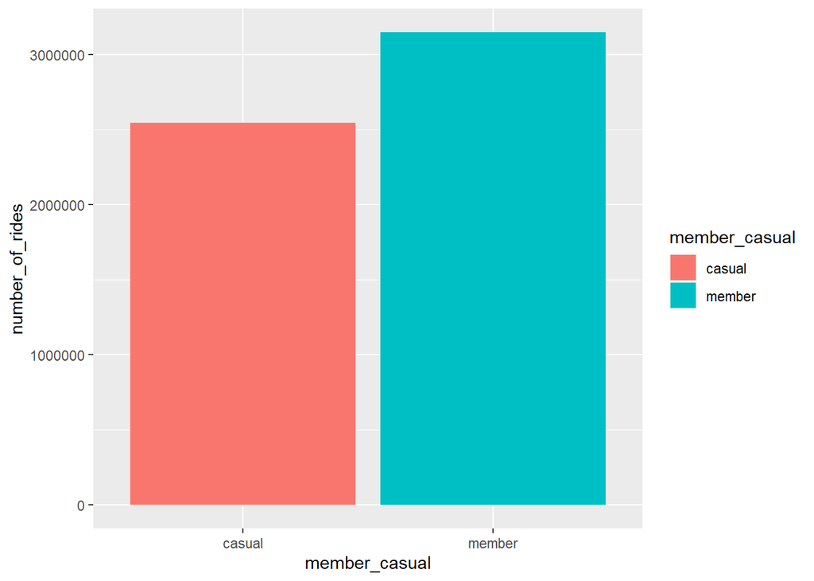

Count the exact of rides by member type

```
## # A tibble: 2 x 2
##   member_casual   count
##   <chr>           <int>
## 1 casual        2543902
## 2 member        3149602
```

As we can see above, the number of annual member are higher than the casual riders. There are total 3149602 or 55.31% riders of annual member while for the casual member, 2543902 or 44.68% riders.

#### average_durations of rides by member type

Looking for the average duration in minute of rides by member type

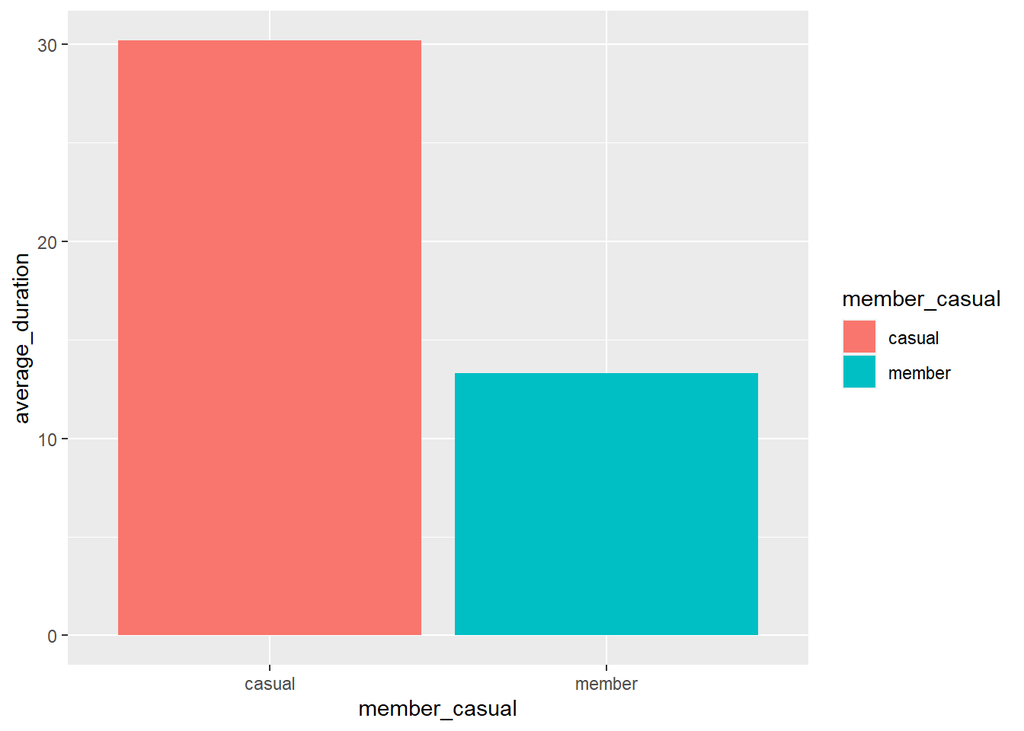

Count the exact average_durations of rides by member type

```
## # A tibble: 2 x 2
##   member_casual ride_length_min
##   <chr>                   <dbl>
## 1 casual                   30.2
## 2 member                   13.3
```

Otherwise from the number of rides. Average duration for Casual riders are higher than annual member. From the data above, we can assume that casual riders rent the bike to cycle around for quite a long distance, but for annual members only bikes to commute to work each day.

But we need more data to accept that assumtion

### Rides by rideable_type

#### Number of rides by rideable_type and member type

Run the data visualization of number_of_rides by rideable_type and member type

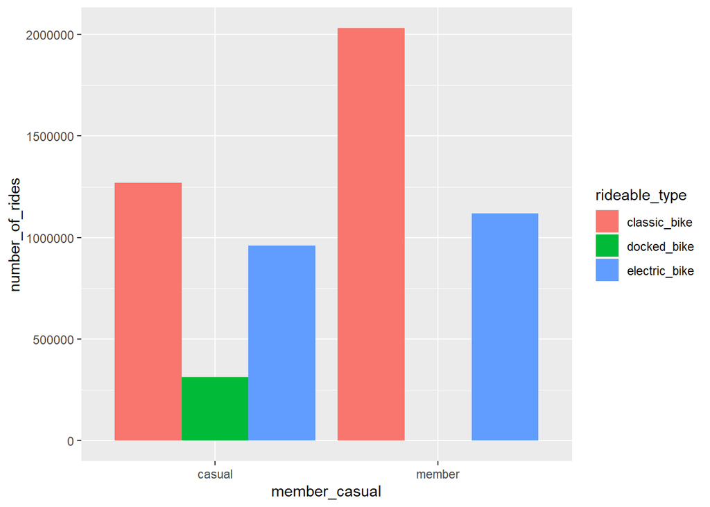

Count the exact number of average_durations by ridable type

```
## # A tibble: 6 x 3
## # Groups:   member_casual [2]
##   member_casual rideable_type   count
##   <chr>         <chr>           <int>
## 1 casual        classic_bike  1270360
## 2 casual        docked_bike    312986
## 3 casual        electric_bike  960556
## 4 member        classic_bike  2031040
## 5 member        docked_bike         1
## 6 member        electric_bike 1118561
```

As we can see from data above. Classic bike is the most popular bicycle type among the three bicycle type, followed by electric bike then docked bike.

#### average_durations of rides by ridable type

Run the data visualization of average_durations by rideable_type and member type

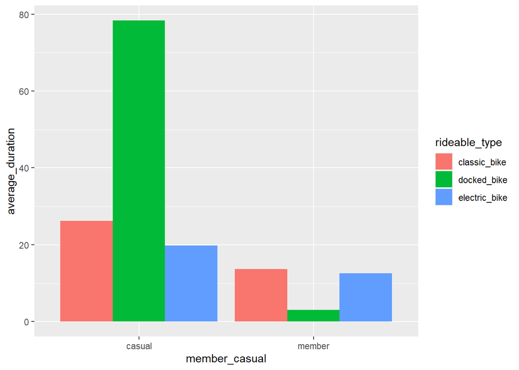

Count the exact number of average_durations by rideable_type and member type

```
## # A tibble: 6 x 3
## # Groups:   member_casual [2]
##   member_casual rideable_type ride_length_min
##   <chr>         <chr>                   <dbl>
## 1 casual        classic_bike             26.2
## 2 casual        docked_bike              78.3
## 3 casual        electric_bike            19.7
## 4 member        classic_bike             13.7
## 5 member        docked_bike               3
## 6 member        electric_bike            12.6
```

From the data above, we can see that docked bike from casual riders are the highest minute ride. After we breakdown member type by each ride type, we can see for each ride type are casual riders are higher than annual member.

### Rides by day of week

#### Number of rides by day of week and member type

Run the data visualization of number_of_rides by day_of_Week - member type

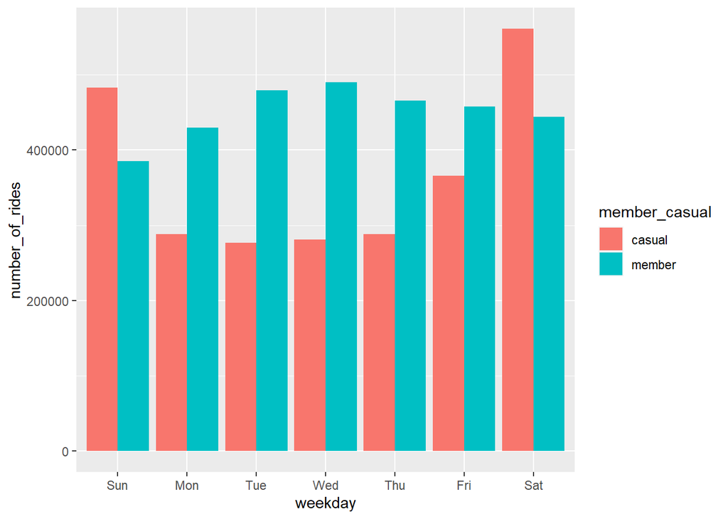

Count the exact number of number_of_rides by day_of_Week - member type

```
## # A tibble: 14 x 3
## # Groups:   member_casual [2]
##    member_casual day_of_Week  count
##    <chr>         <ord>        <int>
##  1 casual        Monday      283436
##  2 casual        Tuesday     276579
##  3 casual        Wednesday   282408
##  4 casual        Thursday    293808
##  5 casual        Friday      391061
##  6 casual        Saturday    570646
##  7 casual        Sunday      445964
##  8 member        Monday      431891
##  9 member        Tuesday     479502
## 10 member        Wednesday   488375
## 11 member        Thursday    466043
## 12 member        Friday      459913
## 13 member        Saturday    444453
## 14 member        Sunday      379425
```

We can see that the number of casual riders is lesser than the number of annual members on the weekday, and otherwise the weekends. From three data above, it is indicate there are different behavior between annual members and casual riders.

#### average_durations of rides by day_of_Week- member_casual

Run the data visualization of average_durations by day_of_Week - member type

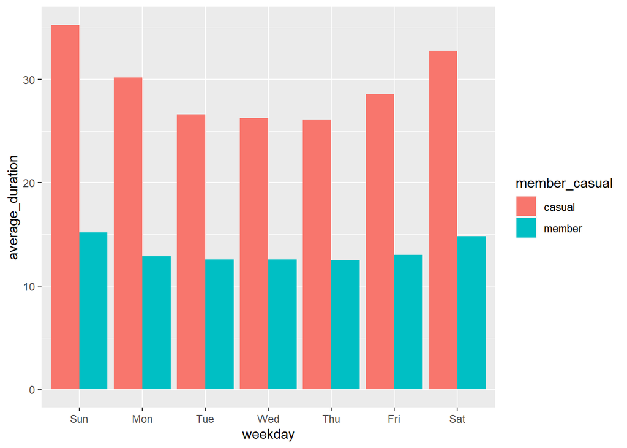

Count the exact number of average_durations by day_of_Week - member type

```
## # A tibble: 14 x 3
## # Groups:   member_casual [2]
##    member_casual day_of_Week ride_length_min
##    <chr>         <ord>                 <dbl>
##  1 casual        Monday                 29.8
##  2 casual        Tuesday                26.6
##  3 casual        Wednesday              26.1
##  4 casual        Thursday               26.4
##  5 casual        Friday                 29.0
##  6 casual        Saturday               32.9
##  7 casual        Sunday                 35.3
##  8 member        Monday                 12.9
##  9 member        Tuesday                12.6
## 10 member        Wednesday              12.6
## 11 member        Thursday               12.5
## 12 member        Friday                 13.1
## 13 member        Saturday               14.9
## 14 member        Sunday                 15.0
```

I assume that even on weekdays casual riders who commute with bikes have a longer distance than annual members. But this assume need to be confirm from the distance on miles or km, and we didn’t have the data to explore it.

Note : We can analyze more deeply with the average per user, using the bikes per day. “what is the total minutes per user per day.

### Rides by trip_hour - member type

#### Number of rides by trip_hour - member type

Run the data visualization of number_of_rides by trip_hour - member type

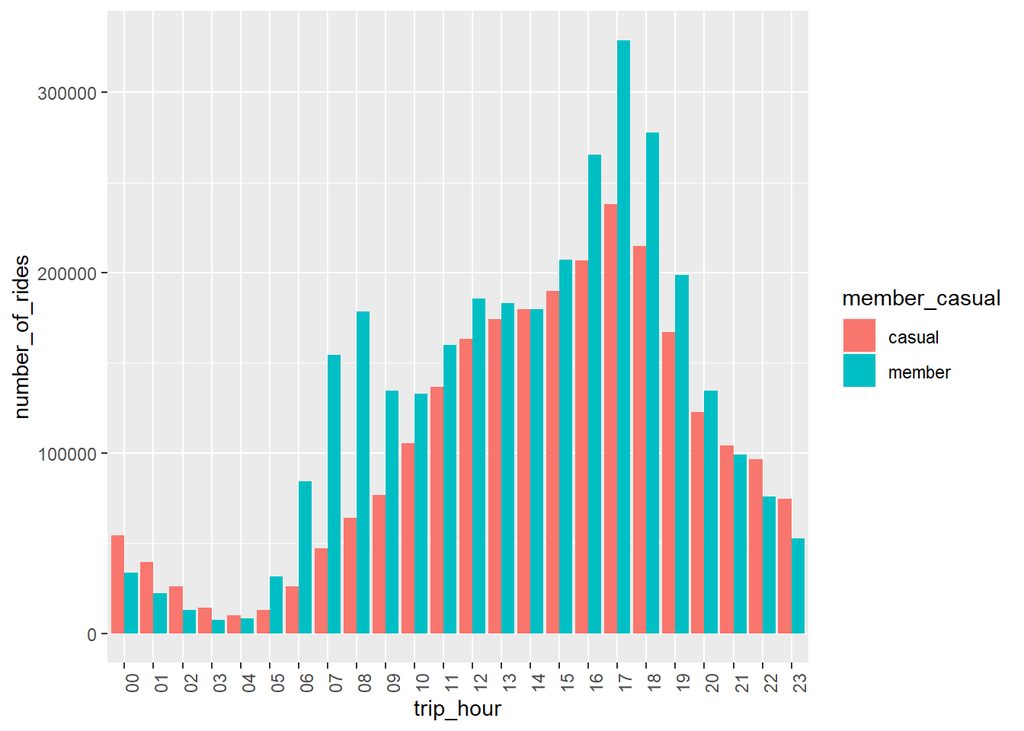

Count the exact number of number_of_rides by trip_hour - member type

```
## # A tibble: 48 x 3
## # Groups:   member_casual [2]
##    member_casual trip_hour count
##    <chr>         <chr>     <int>
##  1 casual        00        54215
##  2 casual        01        39531
##  3 casual        02        25785
##  4 casual        03        14161
##  5 casual        04        10016
##  6 casual        05        12679
##  7 casual        06        25976
##  8 casual        07        47194
##  9 casual        08        64083
## 10 casual        09        76695
## # ... with 38 more rows
```

From data above, we can see that both of casual riders and annual members most of rides bicycle during evening time from 4pm - 6pm, but number gets lesser and lesser when the time close to 4pm in the morning. When morning peak hour 6 - 8 am, there is an increasing user for annual member.

#### average_durations of rides by trip_hour - member type

Run the data visualization of average_durations by trip_hour - member type

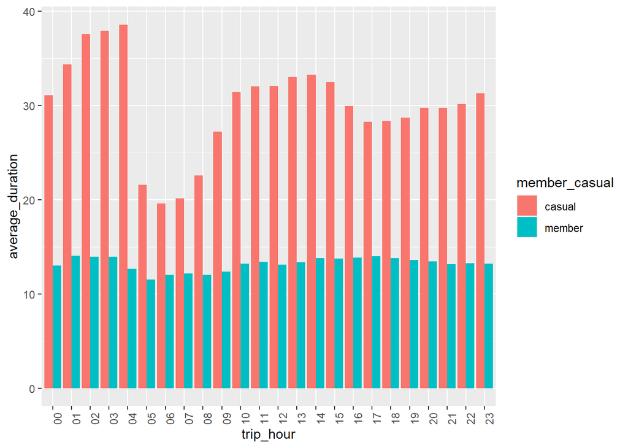

Count the exact number of average_durations by trip_hour - member type

```
## # A tibble: 48 x 3
## # Groups:   member_casual [2]
##    member_casual trip_hour ride_length_min
##    <chr>         <chr>               <dbl>
##  1 casual        00                   31.1
##  2 casual        01                   34.3
##  3 casual        02                   37.6
##  4 casual        03                   37.9
##  5 casual        04                   38.6
##  6 casual        05                   21.6
##  7 casual        06                   19.6
##  8 casual        07                   20.2
##  9 casual        08                   22.6
## 10 casual        09                   27.2
## # ... with 38 more rows
```

This behavior difference can indicate that casual riders have a longer duration, due to longer rides compared to annual members.

### Rides by trip_hour - member type per each day_of_week (facet)

#### Number of rides by trip_hour - member type per each day_of_week (facet)

Run the data visualization of number_of_rides by day_of_Week - member type

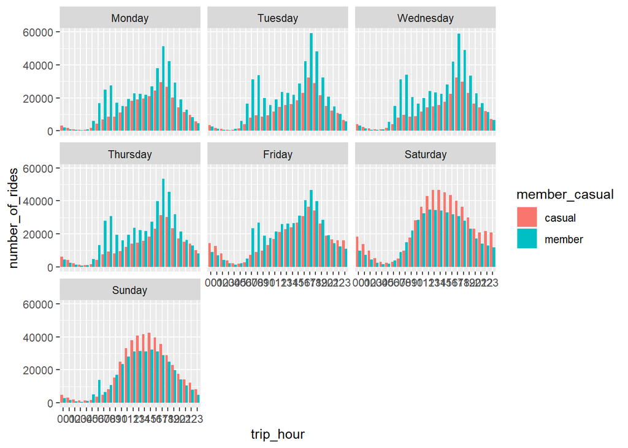

Count the exact number of average_durations

```
## # A tibble: 336 x 4
## # Groups:   member_casual, day_of_Week [14]
##    member_casual day_of_Week trip_hour count
##    <chr>         <ord>       <chr>     <int>
##  1 casual        Monday      00         3126
##  2 casual        Monday      01         1848
##  3 casual        Monday      02         1084
##  4 casual        Monday      03          709
##  5 casual        Monday      04          761
##  6 casual        Monday      05         1749
##  7 casual        Monday      06         4219
##  8 casual        Monday      07         6850
##  9 casual        Monday      08         8655
## 10 casual        Monday      09         8705
## # ... with 326 more rows
```

The trend is almost the same as the number of rides as what we saw previously for the weekday.The number of riders getting higher on morning peak hour and evening peak hours

Behavioral differences can be seen on weekends or weekdays, there are more annual members who rent the bicycle to commute to work on weekdays, and on weekend there are more casual riders who rent the bicycle to tour around, even though it looks like the number of them (casual riders and annual members) on weekends is not as much as weekdays

### Rides that has start and end bike in same station

#### Number of rides that has start and end bike in same station

Run the data visualization of number_of_rides that has start and end bike in same station

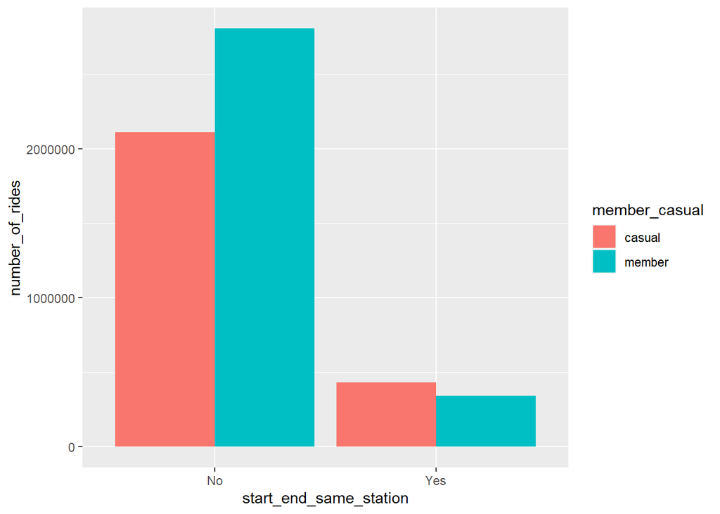

Count the exact number of riders that has start and end bike in same station

```
## # A tibble: 4 x 3
## # Groups:   member_casual [2]
##   member_casual start_end_same_station   count
##   <chr>         <chr>                    <int>
## 1 casual        No                     2111317
## 2 casual        Yes                     432585
## 3 member        No                     2807071
## 4 member        Yes                     342531
```

As we can see from bar chart above, that there are only a few riders who will return the bike on the same station where they rented the bike. It is mean that the riders usially will ride the bicycle to another place and return the bicycle there.

### Rides that has start and end bike in same station per day_of_week (facet)

#### Number of rides that has start and end bike in same station

Run the data visualization of number_of_rides that has start and end bike in same station per day_of_week (facet)

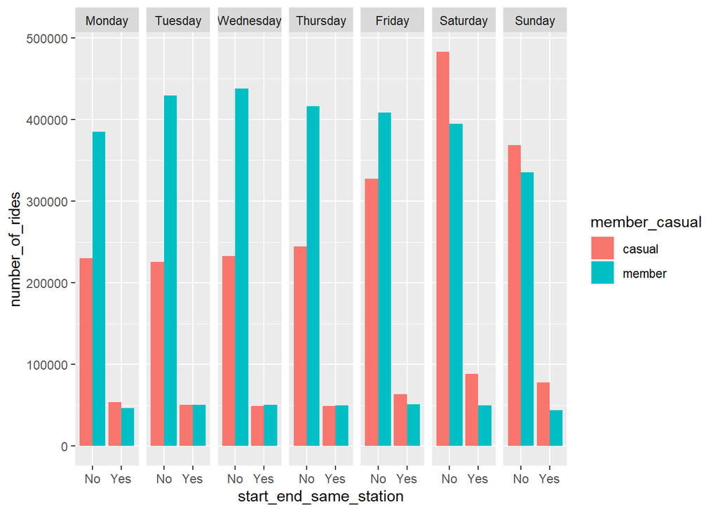

Count the exact number of rides that has start and end bike in same station per day_of_week (facet)

[output not shown]

We can see that there are more annual members who rent and bike the bicyle to another place and return the bicycle at another station on weekdays as compared the casual riders. The annual members who need to commute to work on weekdays will usually rent bicycle to cycle to the workplace and return bicycle at the station nearby the workplace.

While for weekends, the number of casual riders and annual members who rent bicycle are almost the same for returning bycyle at different station.

### Rides by month by month and member type

Run the data visualization of number_of_rides by month and member type

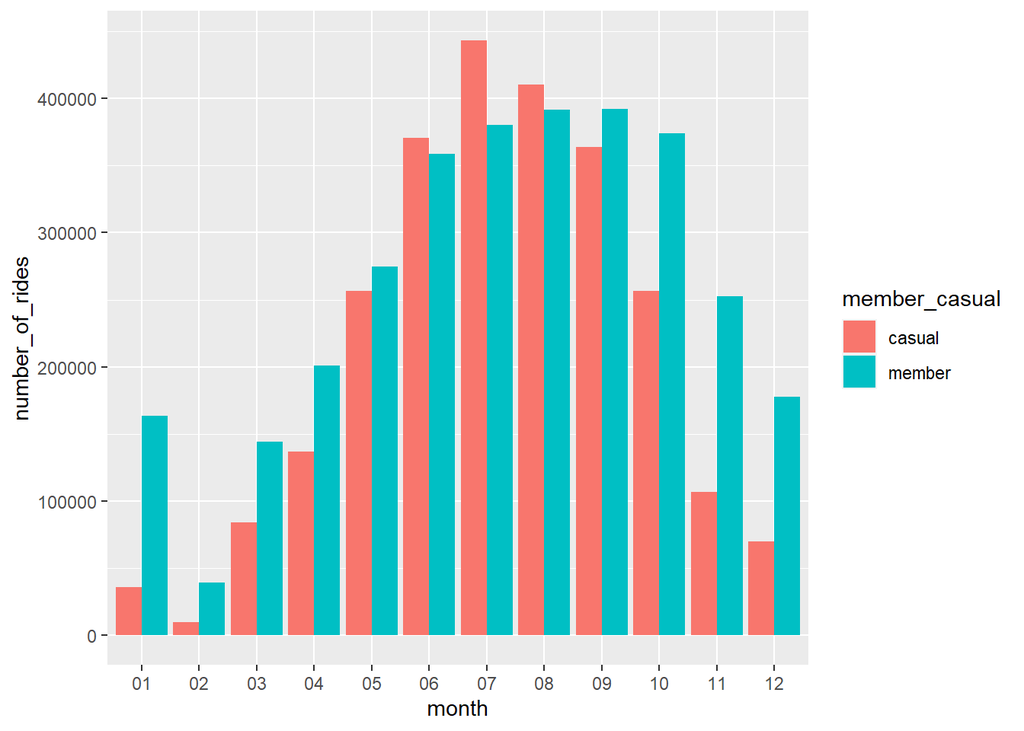

Count the exact number of rides by month and member type

```
## # A tibble: 24 x 3
## # Groups:   member_casual [2]
##    member_casual month  count
##    <chr>         <chr>  <int>
##  1 casual        01     35898
##  2 casual        02     10083
##  3 casual        03     83968
##  4 casual        04    136804
##  5 casual        05    256448
##  6 casual        06    370406
##  7 casual        07    443063
##  8 casual        08    410428
##  9 casual        09    363520
## 10 casual        10    256545
## # ... with 14 more rows
```

Note : Winter : December to February Spring : March to May Summer : June to August Autumn : September to November

#### total duration of rides by month and member type

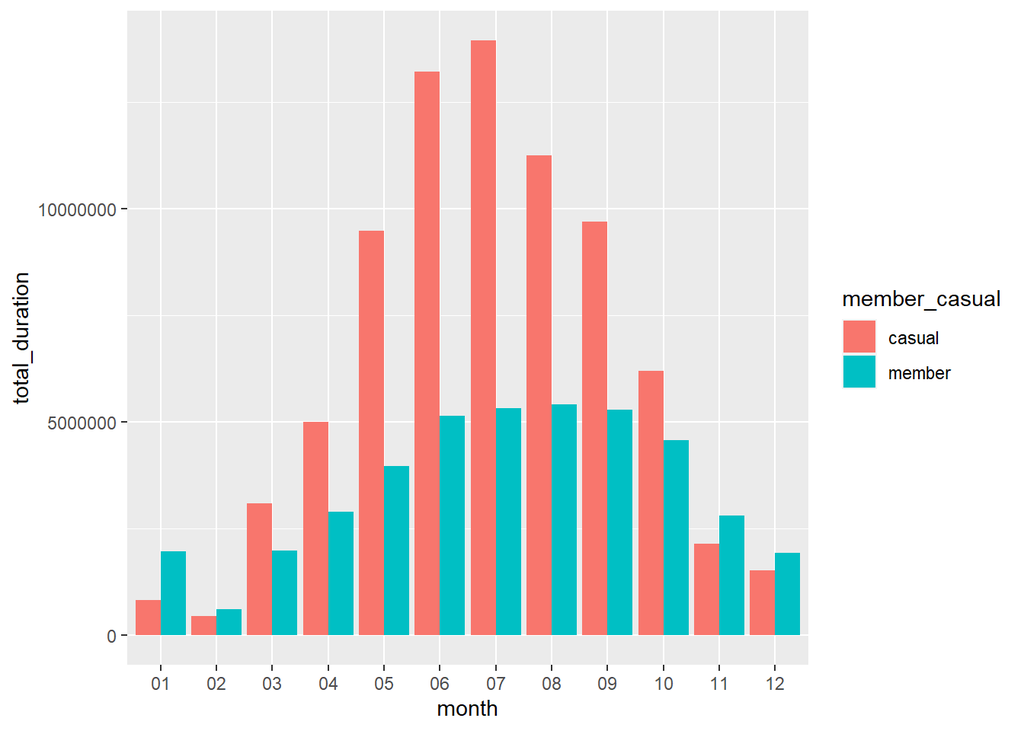

Count the exact number of average_durations by month and member type

```
## # A tibble: 24 x 3
## # Groups:   member_casual [2]
##    member_casual month total_duration
##    <chr>         <chr>          <dbl>
##  1 casual        01            835340
##  2 casual        02            447742
##  3 casual        03           3095822
##  4 casual        04           5006144
##  5 casual        05           9484143
##  6 casual        06          13199758
##  7 casual        07          13932806
##  8 casual        08          11236005
##  9 casual        09           9696021
## 10 casual        10           6198340
## # ... with 14 more rows
```

In bar chart above, we can see the total duration of riding for each month. We can see that as winter approaches, there is a decrease in riders and after winter the riders start to increase.

This shows the behavior of riders when faced with several seasons, especially in winter, people may not use bicycles and will use other transportation.

Note: for recommendations to Cyclistic company and solutions to existing problems will be explained in power point